# Homework 9

Ainesh Mohan

## Problem 1 More regression with `mtcars` (12 points; 2 pts each)

In lecture, we worked briefly with the `mtcars` data set. Let’s get more regression practice by working with it some more.

### a) background

Run `?mtcars` in the console (please **do not** add it to this `Rmd` file) and briefly read the help page. Specifically, take note of the following:

1. What is the source of this data?
2. What is this data set measuring (i.e., what was the response variable in the original study, at least based on the brief description in the R documentation)?
3. What predictors are available and what do they mean?
1. Source of the Data: The data was extracted from the 1974 Motor Trend US magazine.
2. Measurements: The dataset comprises fuel consumption and 10 aspects of automobile design and performance for 32 automobiles (1973–74 models). The primary response variable in the original study appears to be miles per gallon (mpg), which measures fuel efficiency.
3. Predictors Available: mpg: Miles per (US) gallon; cyl: Number of cylinders; disp: Displacement (cubic inches); hp: Gross horsepower; drat: Rear axle ratio; wt: Weight (1,000 lbs); qsec: 1/4 mile time (time it takes to travel a quarter mile from a standstill); vs: Engine shape (0 = V-shaped, 1 = straight); am: Transmission (0 = automatic, 1 = manual); gear: Number of forward gears; carb: Number of carburetors

You may want to also run `head(mtcars, 10)` or `View(mtcars)` to inspect the data frame briefly before moving on.

### b) Fitting a model

Use `lm` to run a regression of `mpg` on a few predictors in the data frame (choose two or three that you think would make a good model– don’t use all ten; we’ll talk about why in later lectures). Make sure to include `data = mtcars` as a keyword argument to `lm` so that R knows what data frame to use.

```r
lm.mtcars = lm(mpg ~ disp + hp + wt, data = mtcars)
```

### c) Interpreting the model

View the summary of your model by uncommenting and running the code below.

```r
summary(lm.mtcars)
```

```
##
## Call:
## lm(formula = mpg ~ disp + hp + wt, data = mtcars)
##
## Residuals:
##    Min     1Q Median     3Q    Max
## -3.891 -1.640 -0.172  1.061  5.861
##
## Coefficients:
##              Estimate Std. Error t value Pr(>|t|)
## (Intercept) 37.105505   2.110815  17.579  < 2e-16 ***
## disp        -0.000937   0.010350  -0.091  0.92851
## hp          -0.031157   0.011436  -2.724  0.01097 *
## wt          -3.800891   1.066191  -3.565  0.00133 **
## ---
## Signif. codes:  0 '***' 0.001 '**' 0.01 '*' 0.05 '.' 0.1 ' ' 1
##
## Residual standard error: 2.639 on 28 degrees of freedom
## Multiple R-squared:  0.8268, Adjusted R-squared:  0.8083
## F-statistic: 44.57 on 3 and 28 DF,  p-value: 8.65e-11
```

Pick one of your predictors and give an interpretation of the estimate and standard error for its coefficient. Be careful in your wording of the interpretation.

Coefficient (Estimate): The coefficient for wt is -3.80091. This means that for each 1,000-pound increase in the weight of the car, the model predicts a decrease in fuel efficiency (miles per gallon, mpg) by approximately 3.80091 units, holding all other variables constant.

Standard Error: The standard error of the coefficient for wt is 1.066191. This value measures the average amount that the coefficient estimate varies with different samples. A smaller standard error suggests that the estimate of the coefficient is more precise.

The t-value and the corresponding p-value indicate that wt is statistically significant in predicting the mpg (since the p-value is much less than 0.05).

So, in summary, the weight of a car is significantly inversely associated with its fuel efficiency, and the estimate of this effect is precise.

Which coefficients are statistically significantly different from zero? How do you know?

The intercept (37.105505), with a p-value < 2e-16 (which is essentially 0). hp (horsepower), with a p-value of 0.01097. wt (weight), with a p-value of 0.00133.

We consider a coefficient to be statistically significantly different from zero if the p-value is below a certain threshold, commonly 0.05 for a 95% confidence level.

### d) Interpreting residuals

What is the Residual Standard Error (RSE) for this model? How many degrees of freedom does it have?

RSE = 2.639; 28 degrees of freedom

What is the value of $R^2$ for this model? (**Hint:** look at the output of `summary`) Give an interpretation of this value.

An $R^2$ of 0.8268 means that approximately 82.68% of the variability in the miles per gallon (mpg) can be explained by the linear relationship with the car’s displacement, horsepower, and weight. This is a relatively high $R^2$, suggesting that the model fits the data well and that these predictors are good at explaining the variation in fuel efficiency among the cars in the dataset.

### e) Adjusted $R^2$

Briefly read about the adjusted $R^2$ [here](https://www.statisticshowto.com/probability-and-statistics/statistics-definitions/adjusted-r2/). What is the adjusted $R^2$ of this model and how does this differ from the usual $R^2$ value? (**Hint:** again, look at the output of `summary`).

Adj $R^2$ is 0.8083. Adjusted $R^2$ differs from the usual $R^2$ in that it accounts for the number of predictors in the model relative to the number of observations. While $R^2$ will always increase when more predictors are added to a model, whether they are significant or not, the adjusted $R^2$ may decrease if the additional predictors do not improve the model enough to offset the penalty for the increased complexity.

### f) CIs for coefficients

Read the documentation for the `confint` function, and use it to generate $95\%$ confidence intervals for the coefficients of your model. Give an interpretation of these confidence intervals.

```r
confint(lm.mtcars)
```

```
##                   2.5 %       97.5 %
## (Intercept) 32.78169625 41.429314293
## disp        -0.02213750  0.020263482
## hp          -0.05458171 -0.007731388
## wt          -5.98488310 -1.616898063
```

Intercept: The model predicts that, when disp, hp, and wt are all zero, the expected mpg will be between 32.78 and 41.43 with 95% confidence. Of course, it’s not realistic to have these predictors at zero, but this intercept forms the baseline of the model.

disp: Since the confidence interval for disp includes zero (-0.02214 to 0.02026), we cannot be 95% confident that the displacement (disp) has a significant effect on the miles per gallon (mpg), as the interval crosses the point of no effect.

hp: The confidence interval for horsepower (hp) ranges from -0.05459 to -0.00773, not containing zero, suggesting that with 95% confidence, we can say that an increase in horsepower is associated with a decrease in fuel efficiency. Specifically, for each additional unit increase in horsepower, the mpg decreases between 0.00773 and 0.05459 miles per gallon, holding other factors constant.

wt: The confidence interval for weight (wt) is from -5.98483 to -1.61690, which also does not include zero. This means that with 95% confidence, we can say that an increase in weight is significantly associated with a decrease in mpg. For each 1,000-pound increase in weight, the mpg decreases between 1.617 and 5.985 miles per gallon, holding other factors constant.

## Problem 2) the `cats` data set (8 points; 2pts each)

The `cats` data set, included in the `MASS` library, contains data recorded from 144 cats. Each row of the data set contains the body weight (`Bwt`, in kgs), heart weight (`Hwt`, in grams) and the sex (`Sex`, levels `'F'` and `'M'`) for one of the cats in the data set.

### a) plotting the data

Create a scatter plot showing heart weight on the y-axis and body weight on the x-axis. Ignore the `Sex` variable in this plot.

```r
library(MASS)
head(cats)
```

```
##   Sex Bwt Hwt
## 1   F 2.0 7.0
## 2   F 2.0 7.4
## 3   F 2.0 9.5
## 4   F 2.1 7.2
## 5   F 2.1 7.3
## 6   F 2.1 7.6
```

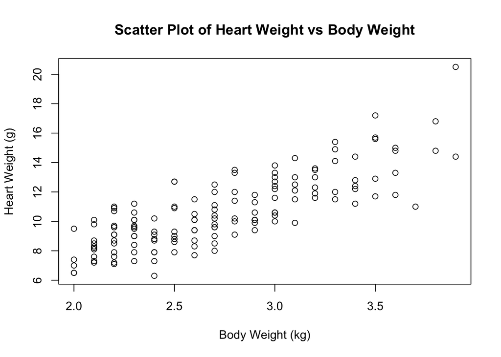

```r
plot(cats$Bwt, cats$Hwt,
     xlab = "Body Weight (kg)",
     ylab = "Heart Weight (g)",
     main = "Scatter Plot of Heart Weight vs Body Weight")
```

Briefly describe what you see. Is there a clear trend in the data?